# Music Clustering from Spotify

Based on Components and Popularity

Atika Dewi Suryani

July 31, 2020

# 1 Intro - What we will do ?

We will try to do a clustering analysis **music bank data from Spotify basedn on the component and popularity** using K-means method. We will also see if we can do a dimensionality reduction using the Principle Components Analysis (PCA).

## 1.1 Datasets

The datasets is acquired through [Kaggle](https://www.kaggle.com/zaheenhamidani/ultimate-spotify-tracks-db).

## 1.2 Library and Setup

We’ll set-up caching for this notebook given how computationally expensive some of the code we will write can get.

```yaml
library(tidyverse)
library(lubridate)
library(cluster)
library(factoextra)
library(ggforce)
library(GGally)
library(scales)
library(cowplot)
library(FactoMineR)
library(factoextra)
library(plotly)
library(dplyr)
library(radarchart)
library(tidyr)
library(fmsb)
library(mlbench)
library(caret)
library(lattice)
```

## 1.3 Import and Check Data

Read data in .csv format

```r
spo <- read.csv("SpotifyFeatures copy.csv", stringsAsFactors = FALSE)
```

Check data type

```r
glimpse(spo)
```

```
#> Rows: 9,999
#> Columns: 19
#> $ genre            <chr> "Movie", "Movie", "Movie", "Movie", "Movie", "Movie"…
#> $ artist_name      <chr> "Henri Salvador", "Martin & les f\x8ees", "Joseph Wi…
#> $ track_name       <chr> "C'est beau de faire un Show", "Perdu d'avance (par …
#> $ track_id         <chr> "0BRjO6ga9RKCKjfDqeFgWV", "0BjC1NfoEOOusryehmNudP", …
#> $ popularity       <int> 0, 1, 3, 0, 4, 0, 2, 15, 0, 10, 0, 2, 4, 3, 0, 0, 0,…
#> $ acousticness     <dbl> 0.61100, 0.24600, 0.95200, 0.70300, 0.95000, 0.74900…
#> $ danceability     <dbl> 0.389, 0.590, 0.663, 0.240, 0.331, 0.578, 0.703, 0.4…
#> $ duration_ms      <int> 99373, 137373, 170267, 152427, 82625, 160627, 212293…
#> $ energy           <dbl> 0.9100, 0.7370, 0.1310, 0.3260, 0.2250, 0.0948, 0.27…
#> $ instrumentalness <dbl> 0.00000000, 0.00000000, 0.00000000, 0.00000000, 0.12…
#> $ key              <chr> "C#", "F#", "C", "C#", "F", "C#", "C#", "F#", "C", "…
#> $ liveness         <dbl> 0.3460, 0.1510, 0.1030, 0.0985, 0.2020, 0.1070, 0.10…
#> $ loudness         <dbl> -1.828, -5.559, -13.879, -12.178, -21.150, -14.970, …
#> $ mode             <chr> "Major", "Minor", "Minor", "Major", "Major", "Major"…
#> $ speechiness      <dbl> 0.0525, 0.0868, 0.0362, 0.0395, 0.0456, 0.1430, 0.95…
#> $ tempo            <dbl> 166.969, 174.003, 99.488, 171.758, 140.576, 87.479, …
#> $ time_signature   <chr> "4-Apr", "4-Apr", "4-May", "4-Apr", "4-Apr", "4-Apr"…
#> $ valence          <dbl> 0.8140, 0.8160, 0.3680, 0.2270, 0.3900, 0.3580, 0.53…
#> $ popular          <chr> "Okay", "Okay", "Okay", "Okay", "Okay", "Okay", "Oka…
```

Data still need to normalise

**Variable Explanation**

- **Genre** : Category of artistic composition, as in music or literature, characterized by similarities in form, style, or subject matter
- **Artist_name** : Artist name
- **Track_name** : Name of track
- **Track_id** : Describes identical number of the track that used by the Spotify for identify the song based on random number
- **Popularity** : Describes the track from-to 1-100 scale of popularity (low-high) based on most play by the user
- **Danceability**: Describes how suitable a track is for dancing based on a combination of musical elements including tempo, rhythm stability, beat strength, and overall regularity. A value of 0.0 is least danceable and 1.0 is most danceable.
- **Energy**: Is a measure from 0.0 to 1.0 and represents a perceptual measure of intensity and activity. Typically, energetic tracks feel fast, loud, and noisy. For example, death metal has high energy, while a Bach prelude scores low on the scale. Perceptual features contributing to this attribute include dynamic range, perceived loudness, timbre, onset rate, and general entropy.
- **Key**: The key the track is in. Integers map to pitches using standard Pitch Class notation. E.g. 0 = C, 1 = C♯/D♭, 2 = D, and so on.
- **Loudness**: The overall loudness of a track in decibels (dB). Loudness values are averaged across the entire track and are useful for comparing relative loudness of tracks. Loudness is the quality of a sound that is the primary psychological correlate of physical strength (amplitude). Values typical range between -60 and 0 db.
- **Mode**: Mode indicates the modality (major or minor) of a track, the type of scale from which its melodic content is derived. Major is represented by 1 and minor is 0.
- **Speechiness**: Speechiness detects the presence of spoken words in a track. The more exclusively speech-like the recording (e.g. talk show, audio book, poetry), the closer to 1.0 the attribute value. Values above 0.66 describe tracks that are probably made entirely of spoken words. Values between 0.33 and 0.66 describe tracks that may contain both music and speech, either in sections or layered, including such cases as rap music. Values below 0.33 most likely represent music and other non-speech-like tracks.
- **Acousticness**: A confidence measure from 0.0 to 1.0 of whether the track is acoustic. 1.0 represents high confidence the track is acoustic.
- **Instrumentalness**: Predicts whether a track contains no vocals. “Ooh” and “aah” sounds are treated as instrumental in this context. Rap or spoken word tracks are clearly “vocal”. The closer the instrumentalness value is to 1.0, the greater likelihood the track contains no vocal content. Values above 0.5 are intended to represent instrumental tracks, but confidence is higher as the value approaches 1.0.
- **Liveness**: Detects the presence of an audience in the recording. Higher liveness values represent an increased probability that the track was performed live. A value above 0.8 provides strong likelihood that the track is live.
- **Valence**: A measure from 0.0 to 1.0 describing the musical positiveness conveyed by a track. Tracks with high valence sound more positive (e.g. happy, cheerful, euphoric), while tracks with low valence sound more negative (e.g. sad, depressed, angry).
- **Tempo**: The overall estimated tempo of a track in beats per minute (BPM). In musical terminology, tempo is the speed or pace of a given piece and derives directly from the average beat duration.
- **Duration_ms**: The duration of the track in milliseconds.
- **Popular** : Group based on the popular’s rate

## 1.4 Data Preprocessing

check any NA data on the table

```r
colSums(is.na(spo))
```

```
#>            genre      artist_name       track_name         track_id
#>                0                0                0                0
#>       popularity     acousticness     danceability      duration_ms
#>                0                0                0                0
#>           energy instrumentalness              key         liveness
#>                0                0                0                0
#>         loudness             mode      speechiness            tempo
#>                0                0                0                0
#>   time_signature          valence          popular
#>                0                0                0
```

No missing data

We need new dataframe that **only** conclude as.numeric datas

```r
spotidy <-  spo %>%
select(c(acousticness, danceability, duration_ms, energy, instrumentalness, liveness, loudness, speechiness, tempo,valence))
```

We need new dataframe that that conclude 1 variable **factor** to be conclude in a popularity grouping

```r
spotidy1 <- spo %>%
select(c(popular, acousticness, danceability, duration_ms, energy, instrumentalness, liveness, loudness, speechiness, tempo,valence))
```

Normalise data on spotidy

```r
# function
normalize <- function(x) {
return ((x - min(x)) / (max(x) - min(x)))
}

# save normalise element to new object
spotidy$acousticness <- normalize(spotidy$acousticness)
spotidy$danceability <- normalize(spotidy$danceability)
spotidy$duration_ms <- normalize(spotidy$duration_ms)
spotidy$energy <- normalize(spotidy$energy)
spotidy$instrumentalness <- normalize(spotidy$instrumentalness)
spotidy$liveness <- normalize(spotidy$liveness)
spotidy$loudness <- normalize(spotidy$loudness)
spotidy$speechiness <- normalize(spotidy$speechiness)
spotidy$tempo <- normalize(spotidy$tempo)
spotidy$valence <- normalize(spotidy$valence)

# check summary of new object
summary(spotidy)
```

```
#>   acousticness      danceability     duration_ms          energy
#>  Min.   :0.00000   Min.   :0.0000   Min.   :0.00000   Min.   :0.0000
#>  1st Qu.:0.01266   1st Qu.:0.4501   1st Qu.:0.04735   1st Qu.:0.4907
#>  Median :0.11256   Median :0.5502   Median :0.05480   Median :0.6839
#>  Mean   :0.24664   Mean   :0.5478   Mean   :0.05747   Mean   :0.6525
#>  3rd Qu.:0.42462   3rd Qu.:0.6514   3rd Qu.:0.06383   3rd Qu.:0.8374
#>  Max.   :1.00000   Max.   :1.0000   Max.   :1.00000   Max.   :1.0000
#>  instrumentalness       liveness          loudness       speechiness
#>  Min.   :0.0000000   Min.   :0.00000   Min.   :0.0000   Min.   :0.00000
#>  1st Qu.:0.0000000   1st Qu.:0.07911   1st Qu.:0.7033   1st Qu.:0.01033
#>  Median :0.0000074   Median :0.11246   Median :0.7857   Median :0.02088
#>  Mean   :0.0341073   Mean   :0.17765   Mean   :0.7589   Mean   :0.05676
#>  3rd Qu.:0.0007373   3rd Qu.:0.23045   3rd Qu.:0.8415   3rd Qu.:0.05316
#>  Max.   :1.0000000   Max.   :1.00000   Max.   :1.0000   Max.   :1.00000
#>      tempo           valence
#>  Min.   :0.0000   Min.   :0.0000
#>  1st Qu.:0.3515   1st Qu.:0.3184
#>  Median :0.4775   Median :0.4852
#>  Mean   :0.4868   Mean   :0.4977
#>  3rd Qu.:0.6012   3rd Qu.:0.6760
#>  Max.   :1.0000   Max.   :1.0000
```

Normalise data on spotidy1

```r
# save normalise element to new object
spotidy1$acousticness <- normalize(spotidy1$acousticness)
spotidy1$danceability <- normalize(spotidy1$danceability)
spotidy1$duration_ms <- normalize(spotidy1$duration_ms)
spotidy1$energy <- normalize(spotidy1$energy)
spotidy1$instrumentalness <- normalize(spotidy1$instrumentalness)
spotidy1$liveness <- normalize(spotidy1$liveness)
spotidy1$loudness <- normalize(spotidy1$loudness)
spotidy1$speechiness <- normalize(spotidy1$speechiness)
spotidy1$tempo <- normalize(spotidy1$tempo)
spotidy1$valence <- normalize(spotidy1$valence)

# check summary of new object
summary(spotidy1)
```

```
#>    popular           acousticness      danceability     duration_ms
#>  Length:9999        Min.   :0.00000   Min.   :0.0000   Min.   :0.00000
#>  Class :character   1st Qu.:0.01266   1st Qu.:0.4501   1st Qu.:0.04735
#>  Mode  :character   Median :0.11256   Median :0.5502   Median :0.05480
#>                     Mean   :0.24664   Mean   :0.5478   Mean   :0.05747
#>                     3rd Qu.:0.42462   3rd Qu.:0.6514   3rd Qu.:0.06383
#>                     Max.   :1.00000   Max.   :1.0000   Max.   :1.00000
#>      energy       instrumentalness       liveness          loudness
#>  Min.   :0.0000   Min.   :0.0000000   Min.   :0.00000   Min.   :0.0000
#>  1st Qu.:0.4907   1st Qu.:0.0000000   1st Qu.:0.07911   1st Qu.:0.7033
#>  Median :0.6839   Median :0.0000074   Median :0.11246   Median :0.7857
#>  Mean   :0.6525   Mean   :0.0341073   Mean   :0.17765   Mean   :0.7589
#>  3rd Qu.:0.8374   3rd Qu.:0.0007373   3rd Qu.:0.23045   3rd Qu.:0.8415
#>  Max.   :1.0000   Max.   :1.0000000   Max.   :1.00000   Max.   :1.0000
#>   speechiness          tempo           valence
#>  Min.   :0.00000   Min.   :0.0000   Min.   :0.0000
#>  1st Qu.:0.01033   1st Qu.:0.3515   1st Qu.:0.3184
#>  Median :0.02088   Median :0.4775   Median :0.4852
#>  Mean   :0.05676   Mean   :0.4868   Mean   :0.4977
#>  3rd Qu.:0.05316   3rd Qu.:0.6012   3rd Qu.:0.6760
#>  Max.   :1.00000   Max.   :1.0000   Max.   :1.0000
```

# 2 Exploratory Data Analysis

## 2.1 Possibility for PCA

We want to see if there is a high correlation between numeric variables. Strong correlation in some variables imply that we can reduce the dimensionality or number of features using the Principle Component Analysis (PCA).

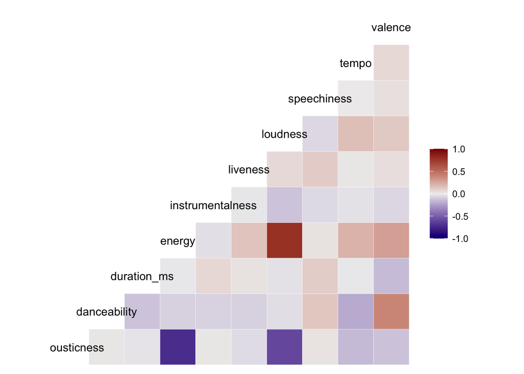

```r
ggcorr(spotidy, low = "navy", high = "darkred")
```

There are some features that has high correlation such as the energy and loudness, valence and energy, tempo and energy, etc. Based on this result, we will try to reduce the dimension using PCA.

# 3 Clustering

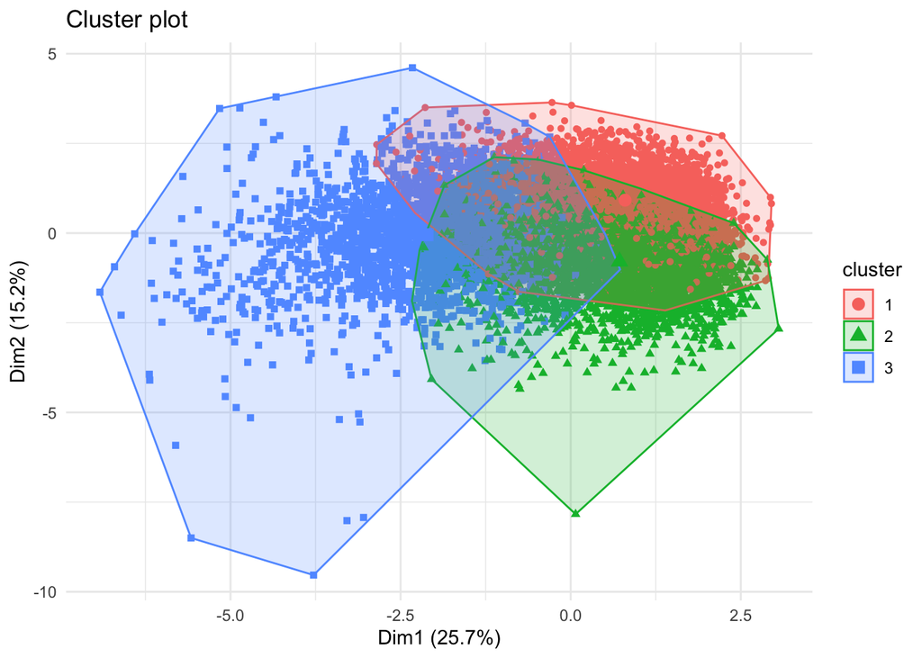

```r
RNGkind(sample.kind = "Rounding")
set.seed(50)
spo_cluster <- kmeans(spotidy, 3)
fviz_cluster(object = spo_cluster, data = spotidy, labelsize = 0) + theme_minimal()
```

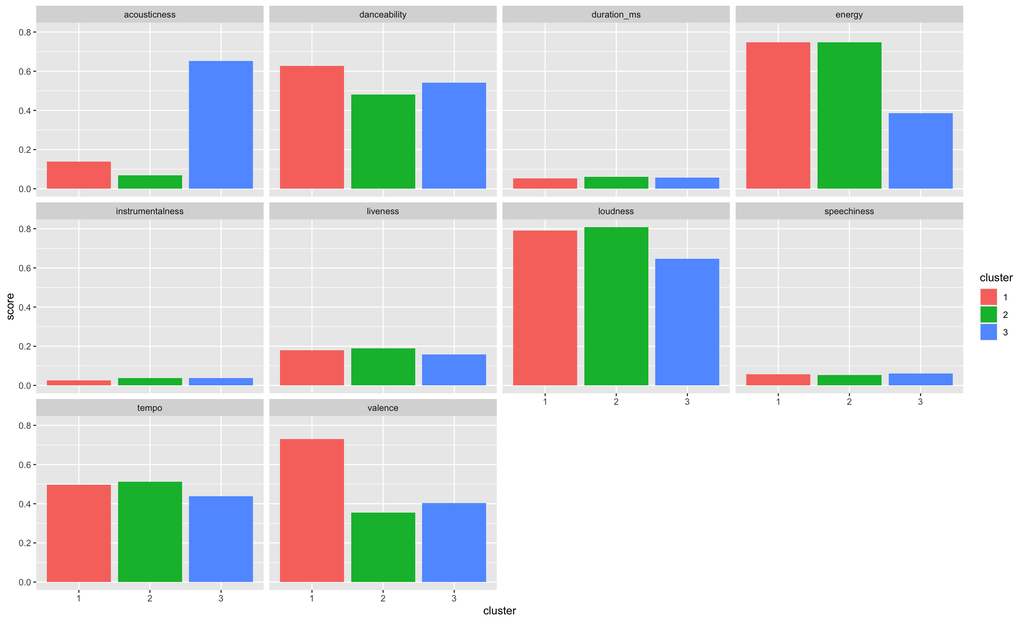

```r
spotidy %>%
mutate(cluster = as.factor(spo_cluster$cluster)) %>%
group_by(cluster) %>%
summarise_all(mean) %>%
pivot_longer(cols = -1, names_to = "type", values_to = "score") %>%
ggplot(aes(x = cluster, y = score)) +
geom_col(aes(fill = cluster)) +
facet_wrap(~type)
```

The data has 3 cluster that has specific characteristic in each cluster

- **Cluster 1** overall has the has the highest energy and danceability
- **Cluster 2** overall has the highest energy and loudness
- **Cluster 3** is the balanced group, but dominance from the `acousticness` side

Cluster based on other popularity

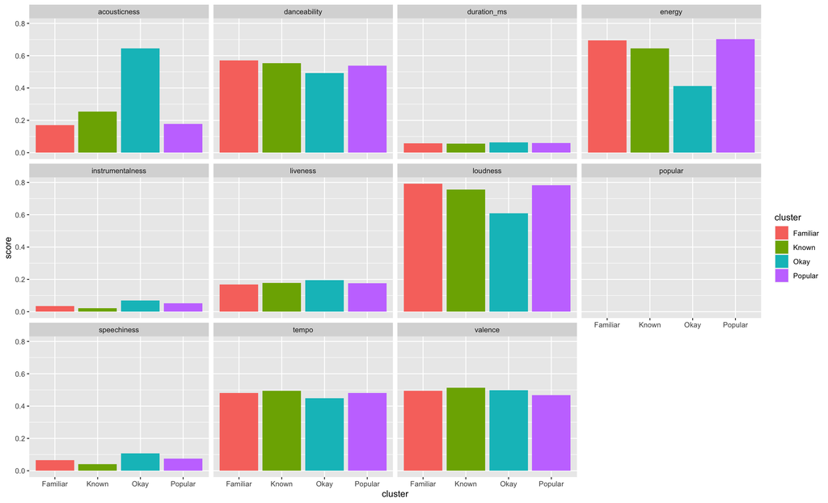

```r
spotidy1 %>%
mutate(cluster = as.factor(spotidy1$popular)) %>%
group_by(cluster) %>%
summarise_all(mean) %>%
pivot_longer(cols = -1, names_to = "type", values_to = "score") %>%
ggplot(aes(x = cluster, y = score)) +
geom_col(aes(fill = cluster)) +
facet_wrap(~type)
```

# 4 PCA Principal component analysis

Statistical procedure that uses an orthogonal transformation to convert a set of observations of possibly correlated variables (entities each of which takes on various numerical values) into a set of values of linearly uncorrelated variables called principal components.

Visualise PCA

[figure not shown]

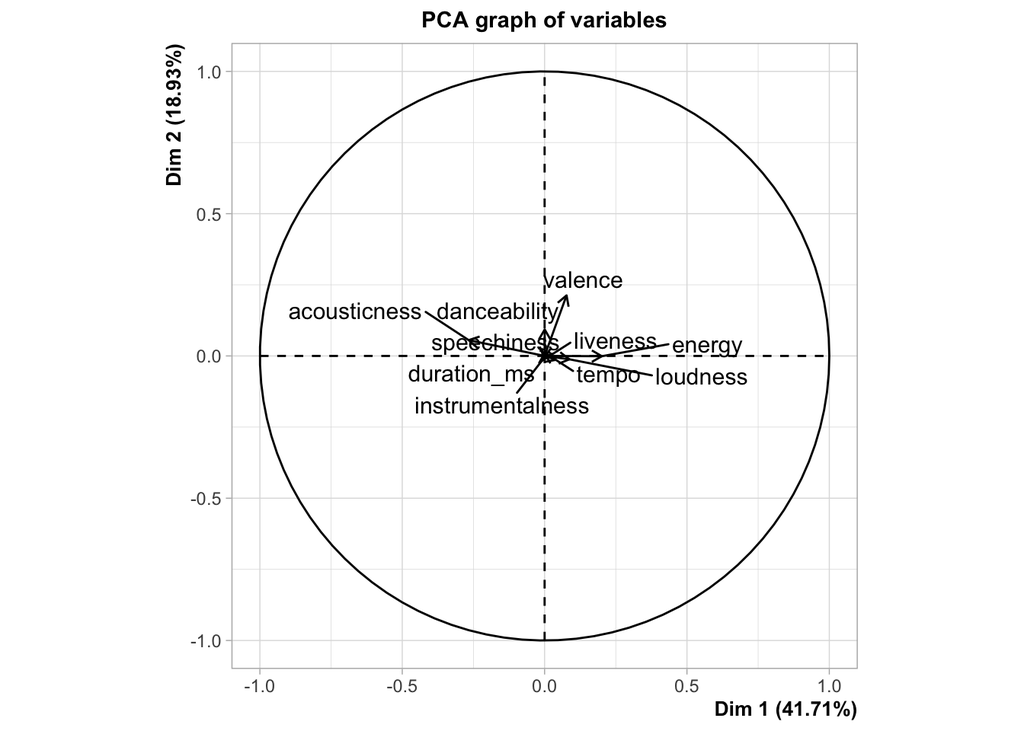

```r
spo_graph <- PCA(X = spotidy, scale.unit = F, graph = T, ncp = 10)
```

# 5 Conclusion